# Human Activity Recognition: Accuracy of Activities in Weight Lifting

## The Model

Considering the number of predictors and the inherent dependencies among them, we used Random Forest to build the prediction model, which exhaustively generates multiple trees and selects the best tree model from the permutation of predictors, averaged over accuracy on the out-of-bag portion of the data.

```r
set.seed(123)
rfmodel <- randomForest(classe~., data=strain, importance=T, ntree=500)
print(rfmodel)
```

```
##
## Call:
##  randomForest(formula = classe ~ ., data = strain, importance = T,      ntree = 500)
##                Type of random forest: classification
##                      Number of trees: 500
## No. of variables tried at each split: 7
##
##         OOB estimate of  error rate: 0.37%
## Confusion matrix:
##      A    B    C    D    E class.error
## A 5576    4    0    0    0   0.0007168
## B    9 3780    8    0    0   0.0044772
## C    0   15 3406    1    0   0.0046756
## D    1    0   23 3189    3   0.0083955
## E    0    0    1    8 3598   0.0024951
```

```r
predict(rfmodel, newdata=stest)
```

```
##  1  2  3  4  5  6  7  8  9 10 11 12 13 14 15 16 17 18 19 20
##  B  A  A  A  A  E  E  E  A  A  A  E  A  A  E  A  A  D  B  B
## Levels: A B C D E
```

The estimate of error rate of 0.37% and near zero classification errors for each classe is an indication of a good fit, perhaps somewhat an overfit. The prediction from the test data is also displayed. We will look at the output of few statistics of this model.

```r
head(varImp(rfmodel, sort=T, scale=F))
```

```
##                        A        B       C       D        E
## roll_belt        0.10386 0.123599 0.14901 0.16466 0.238025
## pitch_belt       0.09857 0.079791 0.16154 0.15131 0.047394
## yaw_belt         0.09735 0.107848 0.12593 0.13824 0.090971
## total_accel_belt 0.02514 0.029686 0.03575 0.03261 0.035702
## gyros_belt_x     0.01335 0.008935 0.01522 0.01208 0.003760
## gyros_belt_y     0.02241 0.020379 0.02637 0.01877 0.008315
```

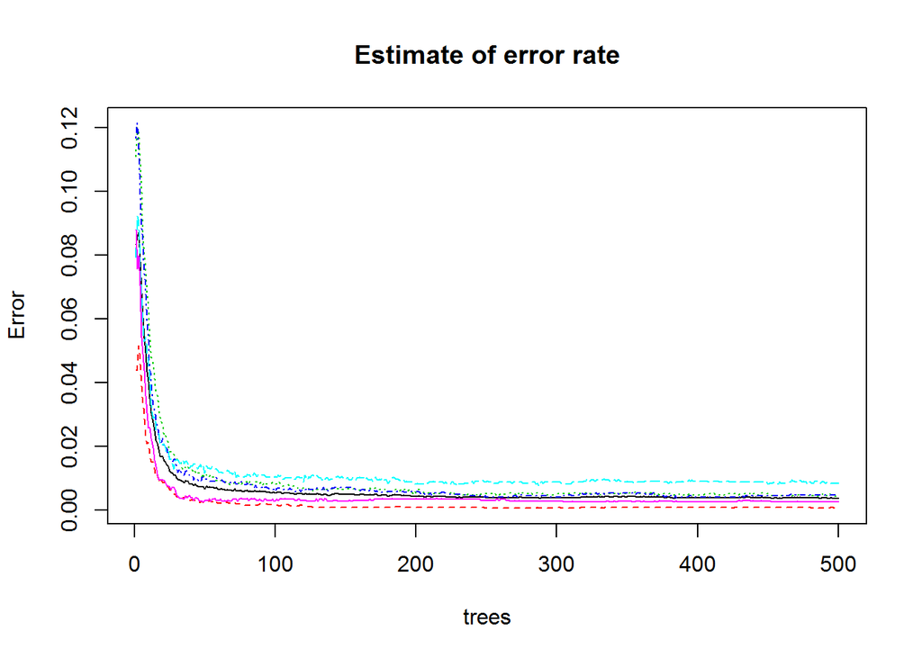

```r
plot(rfmodel, main="Estimate of error rate")
```

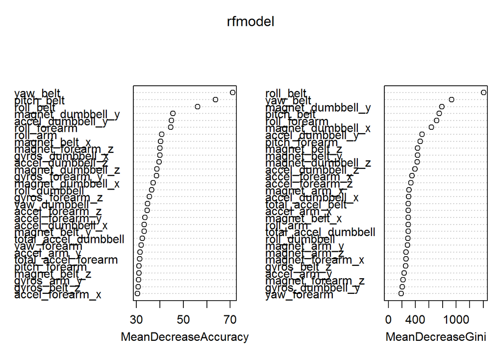

```r
varImpPlot(rfmodel, sort=T)
```

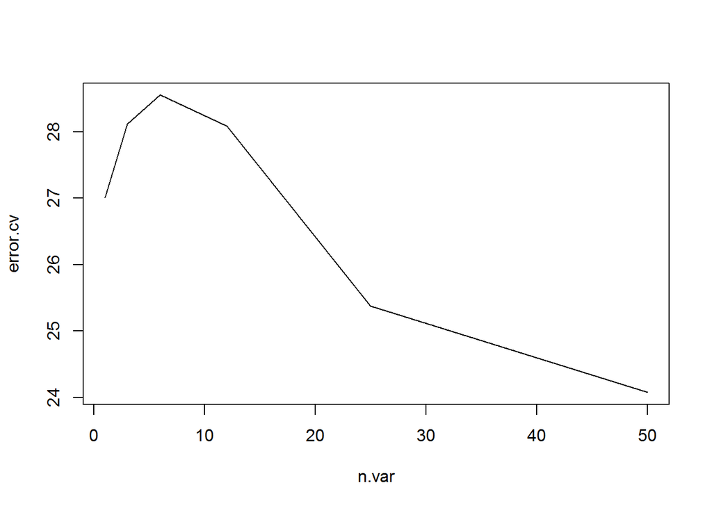

```r
cv <- rfcv(stest[,-1],stest[,1],cv.fold=10)
with(cv, plot(n.var, error.cv, type="l"))
```